# UNICEF Global Health Indicators: A Data-Driven Analysis

## 5 Visualisation 4: Global Vaccination Trend Over Time

**Plot: Time Series — Every individual year shown on x-axis**

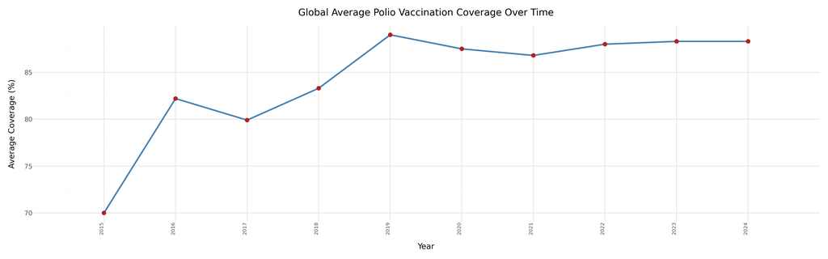

**Figure 4:** Time Series — Global Polio Vaccination Trend (every year on x-axis, 90° labels)

```python
df_time = (
    df_merged.drop_nulls(subset=['year', 'polio_vaccine_pct'])
    .filter(pl.col('year').is_not_null())
    .group_by('year')
    .agg(pl.col('polio_vaccine_pct').mean().round(1))
    .sort('year')
)

min_yr = int(df_time['year'].min())
max_yr = int(df_time['year'].max())
year_breaks = list(range(min_yr, max_yr + 1))

time_plot = (
    ggplot(df_time, aes(x='year', y='polio_vaccine_pct'))
    + geom_line(color='steelblue', size=1.2)
    + geom_point(color='#b22222', size=2.5)
    + scale_x_continuous(breaks=year_breaks, limits=[min_yr - 0.5, max_yr + 0.5])
    + theme_minimal()
    + labs(title='Global Average Polio Vaccination Coverage Over Time',
           x='Year', y='Average Coverage (%)')
    + theme(figure_size=(16, 5), axis_text_x=element_text(angle=90, ha='right', size=7))
)
time_plot.save('time_series_plot.png', width=16, height=5, dpi=300, verbose=False)
```

## 6 Conclusion

The four visualisations collectively paint a clear picture of the **global state of infant health in 2019** and across time:

[output not shown]

> **Data Sources:** UNICEF Indicator Dataset (Polio Vaccination & Breastfeeding), World Bank Metadata (GDP per capita, Life Expectancy, Population). All analysis conducted using Polars (Python) with cross-sectional comparisons anchored to **2019** for methodological consistency.